# Ford GoBike System Data Analysis

# Investigation Overview

This analysis is basically to know the average time used by our member to reach their destination and to know which of the week and day that thsy used the service more

# Dataset overview

The dataset consist of the duration of commur in seconds of over 180,000 observation. The other attribution include member age, user type, member gender and if bike is for all trip or not

## Distribution of duration in minute

The distrution in minute take on very high value from 0-1000 from about 180k dataset. The distribution is unimodal at around to minute and is more normal than how it is on linear scale

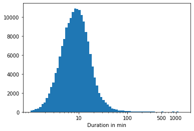

## Distribution of age

Age is also unimodal and shows that people between 20years and 40years are the one using the bike system frequently althought people of over 60 years used the bike but their are filtered out for the rest of the analysis

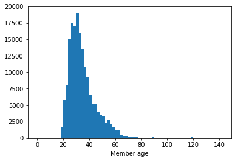

## Correlation between duration and age

The scatter plot shows that the age does not affect the duration used by the member to reach theie destination

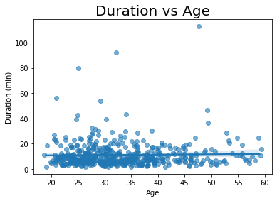

# Average duration trip by weekday and hours

The average hours used tends to increase during the weekend this is a resort the most of the weekend rides are basically for recreationa and not working as mid-week

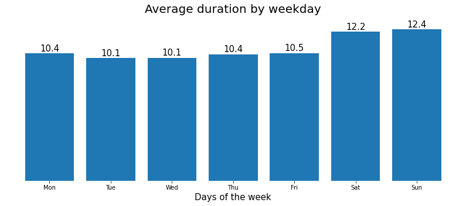

# Percentage of ride by weekday and hour

Percentage of rides tends to be lower during the weekend shows that memeber are basically using bike to transit to work to and fro in other to reach their places of work as soon as possible since bike can move freely in traffic than cars

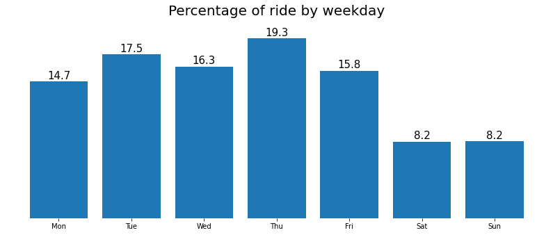

## Percentage of ride by Hour of the day

This justify our assumption that people used the bike for transit to work mostly. There seems to be strong interaction on hour of the day that people rides most which are specifically between 7am-8am and 4pm-5pm which the respective time member go to work and return back from work

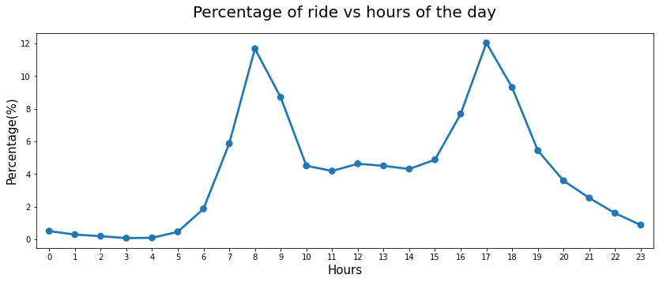

# Percentage by gender and Their average duration

Male are more than female riding the bike and spend less time to reach their destination than femlae, this turns out as exepected already

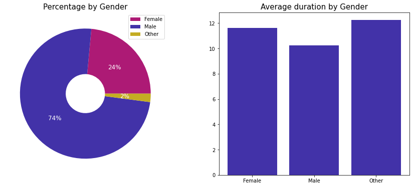

## Percentage to user type and their average ride duration

Suscriber are 91% percent of people riding and they spend less duration time than the customer, this is futher need to be investgated in future analysis

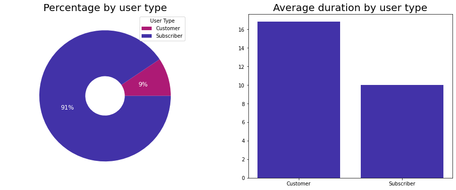

### what is the average duration type by each user type ?

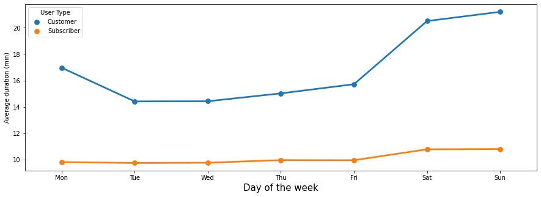

## Average duration vs hours of the day by user type

Customer generally have long duartion time than suscriber almost at every our of the day than their fellow suscriber

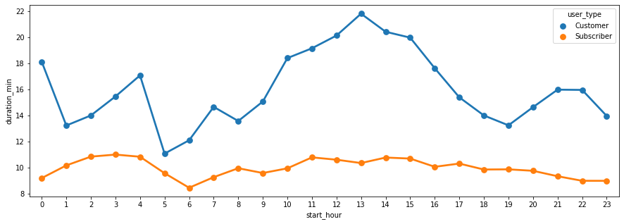